# Practical Machine Learning - Project

Scott Brown

November 30, 2018

# Background

Using devices such as Jawbone Up, Nike FuelBand, and Fitbit it is now possible to collect a large amount of data about personal activity relatively inexpensively. These type of devices are part of the quantified self movement - a group of enthusiasts who take measurements about themselves regularly to improve their health, to find patterns in their behavior, or because they are tech geeks. One thing that people regularly do is quantify how much of a particular activity they do, but they rarely quantify how well they do it.

In this project, your goal will be to use data from accelerometers on the belt, forearm, arm, and dumbell of 6 participants. They were asked to perform barbell lifts correctly and incorrectly in 5 different ways. More information is available from the website here: http://web.archive.org/web/20161224072740/http:/groupware.les.inf.puc-rio.br/har (see the section on the Weight Lifting Exercise Dataset).

# Data

The training data for this project are available here:

https://d396qusza40orc.cloudfront.net/predmachlearn/pml-training.csv

The test data are available here:

https://d396qusza40orc.cloudfront.net/predmachlearn/pml-testing.csv

# Data Processing and General Prep (Library Load)

```r
# Load relevant libraries and data set

library(caret)
library(rattle)
```

```r
library(corrplot)
library(rpart)
library(rpart.plot)
library(RColorBrewer)
library(randomForest)
# Set seed for random numbers
set.seed(80451)

# Download data sets
train_data <- read.csv(url("https://d396qusza40orc.cloudfront.net/predmachlearn/pml-training.csv"))
test_data  <- read.csv(url("https://d396qusza40orc.cloudfront.net/predmachlearn/pml-testing.csv"))

# Remove NA data and near 0 variance
train_data <- train_data[, -nearZeroVar(train_data)]
train_data <- train_data[,(sapply(train_data, function(x) mean(is.na(x))) > 0.9)==FALSE]
train_data <- train_data[, -(1:5)]


# Partition training set further into two subsets
train_subsetdata  <- createDataPartition(train_data$classe, p=0.75, list=FALSE)
train_subsetdata_train <- train_data[train_subsetdata, ]
train_subsetdata_test  <- train_data[-train_subsetdata, ]

# Display dimensions of subset data
dim(train_subsetdata_train)
```

```
## [1] 14718    54
```

```r
dim(train_subsetdata_test)
```

```
## [1] 4904   54
```

```r
#head(train_subsetdata_train)
#str(train_subsetdata_train)
```

# Exploratory Analysis

For our initial exploration of the data we will run a correlation matrix to visualize some of the potentially key relationships in the data.

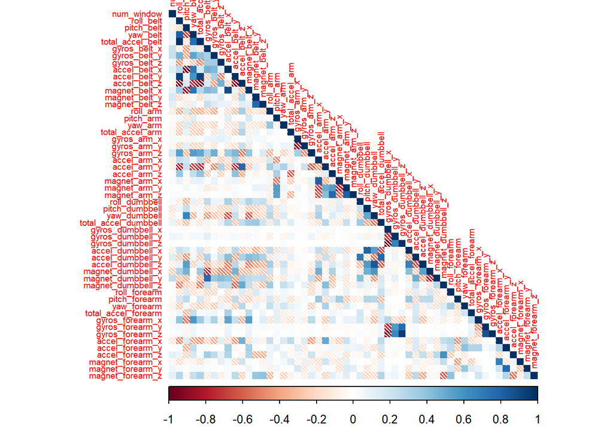

```r
# Display the correlation matrix
corrplot(cor(train_subsetdata_train[,-54]), method = "shade", type = "lower", tl.cex = 0.6)
```

As illustrated in the matrix above, there aren’t a significant number of variables with a high correlation.

# Decision Models

We will run to separate models and select the one with the higher level of precision for our prediction exercise.

## 1 - Decision Tree

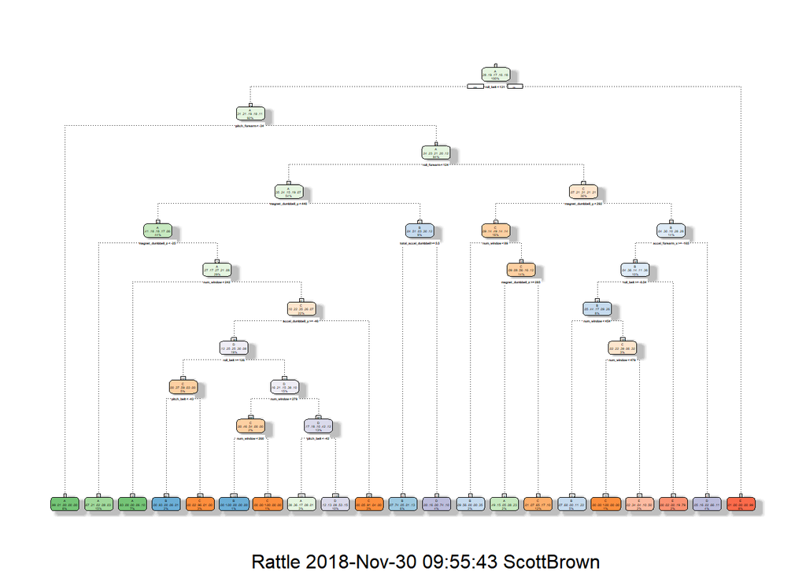

```r
#Process and display decision tree
model_decisiontree <- rpart(classe ~ ., data=train_subsetdata_train, method="class")
fancyRpartPlot(model_decisiontree)
```

```r
#Run prediction on subset test data
predict_decisiontree <- predict(model_decisiontree, newdata=train_subsetdata_test, type="class")

#Display confusion matrix to display accuracy of prediction
confmatrix_decisiontree <- confusionMatrix(predict_decisiontree, train_subsetdata_test$classe)
confmatrix_decisiontree
```

```
## Confusion Matrix and Statistics
##
##           Reference
## Prediction    A    B    C    D    E
##          A 1264  209   44  114   80
##          B   40  537   13   39  114
##          C    9   49  742  116   52
##          D   74  104   51  503  114
##          E    8   50    5   32  541
##
## Overall Statistics
##
##                Accuracy : 0.7314
##                  95% CI : (0.7188, 0.7438)
##     No Information Rate : 0.2845
##     P-Value [Acc > NIR] : < 2.2e-16
##
##                   Kappa : 0.6578
##  Mcnemar's Test P-Value : < 2.2e-16
##
## Statistics by Class:
##
##                      Class: A Class: B Class: C Class: D Class: E
## Sensitivity            0.9061   0.5659   0.8678   0.6256   0.6004
## Specificity            0.8726   0.9479   0.9442   0.9163   0.9763
## Pos Pred Value         0.7387   0.7227   0.7665   0.5946   0.8506
## Neg Pred Value         0.9590   0.9010   0.9713   0.9258   0.9157
## Prevalence             0.2845   0.1935   0.1743   0.1639   0.1837
## Detection Rate         0.2577   0.1095   0.1513   0.1026   0.1103
## Detection Prevalence   0.3489   0.1515   0.1974   0.1725   0.1297
## Balanced Accuracy      0.8894   0.7569   0.9060   0.7710   0.7884
```

The accuracy of the decision tree model is 0.7314437

Now we’ll look at a different decision model and compare the accuracy.

## Random Forest

```r
# Process and display model
rf_crossvalidation <- trainControl(method="cv", number=3)
model_randomforest <- train(classe ~ ., data=train_subsetdata_train, method="rf", trControl=rf_crossvalidation)
model_randomforest$finalModel
```

```
##
## Call:
##  randomForest(x = x, y = y, mtry = param$mtry)
##                Type of random forest: classification
##                      Number of trees: 500
## No. of variables tried at each split: 27
##
##         OOB estimate of  error rate: 0.2%
## Confusion matrix:
##      A    B    C    D    E  class.error
## A 4183    1    0    0    1 0.0004778973
## B    7 2839    2    0    0 0.0031601124
## C    0    3 2564    0    0 0.0011686794
## D    0    0    8 2403    1 0.0037313433
## E    0    0    0    6 2700 0.0022172949
```

```r
#Run prediction on subset test data
predict_randomforest <- predict(model_randomforest, newdata=train_subsetdata_test)

#Display confusion matrix to display accuracy of prediction
confmatrix_randomforest <- confusionMatrix(predict_randomforest, train_subsetdata_test$classe)
confmatrix_randomforest
```

```
## Confusion Matrix and Statistics
##
##           Reference
## Prediction    A    B    C    D    E
##          A 1395    0    0    0    0
##          B    0  949    0    0    0
##          C    0    0  855    1    0
##          D    0    0    0  803    3
##          E    0    0    0    0  898
##
## Overall Statistics
##
##                Accuracy : 0.9992
##                  95% CI : (0.9979, 0.9998)
##     No Information Rate : 0.2845
##     P-Value [Acc > NIR] : < 2.2e-16
##
##                   Kappa : 0.999
##  Mcnemar's Test P-Value : NA
##
## Statistics by Class:
##
##                      Class: A Class: B Class: C Class: D Class: E
## Sensitivity            1.0000   1.0000   1.0000   0.9988   0.9967
## Specificity            1.0000   1.0000   0.9998   0.9993   1.0000
## Pos Pred Value         1.0000   1.0000   0.9988   0.9963   1.0000
## Neg Pred Value         1.0000   1.0000   1.0000   0.9998   0.9993
## Prevalence             0.2845   0.1935   0.1743   0.1639   0.1837
## Detection Rate         0.2845   0.1935   0.1743   0.1637   0.1831
## Detection Prevalence   0.2845   0.1935   0.1746   0.1644   0.1831
## Balanced Accuracy      1.0000   1.0000   0.9999   0.9990   0.9983
```

# Prediction

The random forest decision tree appears to provide the most accurate prediction. As such, we will use that model with the test data to predict the quiz results.

```r
predict(model_randomforest, newdata=test_data)
```

```
##  [1] B A B A A E D B A A B C B A E E A B B B
## Levels: A B C D E
```